# Practical Machine Learning Project

Marion Joncheres

## Background

Using devices such as Jawbone Up, Nike FuelBand, and Fitbit, it is now possible to collect a large amount of data about personal activity relatively inexpensively. These devices are part of the quantified self movement – a group of enthusiasts who take measurements about themselves regularly. That people regularly quantify how much of a particular activity they do, but they rarely quantify how well they do it. More information is available here: http://groupware.les.inf.puc-rio.br/har. We will use the datafrom accelerometers placed on differents body parts of 6 participants who perform barbell lifts. They can do it correctly and incorrectly, in 5 different ways (the “classe” variable): according to specifications (“A”), throwing the elbows to the front (“B”), lifting dumbbell only halfway (“C”), lowering dumbbell only halfway (“D”), throwing hips to the front (“E”). Our goal is to build a prediction model to predict the “classe” for 20 different test cases.

## Data pre-processing and cleaning

Load required packages

```r
library(caret)
```

```r
library(rpart)
library(rpart.plot)
library(randomForest)
library(knitr)
```

Load and read data

```r
dataset_url <- "https://d396qusza40orc.cloudfront.net/predmachlearn/pml-training.csv"
download.file(dataset_url, "pml-training.csv")
training = read.csv("pml-training.csv")
dataset_url <- "https://d396qusza40orc.cloudfront.net/predmachlearn/pml-testing.csv"
download.file(dataset_url, "pml-testing.csv")
testing = read.csv("pml-testing.csv")
dim(training); dim(testing)
```

```
## [1] 19622   160
```

```
## [1]  20 160
```

Split training set between subtraining and subtesting sets, to keep the testing data for quiz prediction

```r
set.seed(3598) # For reproducibile purpose
inTrain <- createDataPartition(training$classe, p=0.6, list=FALSE)
subtraining <- training[inTrain, ]
subtesting <- training[-inTrain, ]
```

Datasets have 160 columns. We can remove some of them, based on unuseful identification columns (5 first ones), columns with to many N/A values (eg > 80%) and Near Zero Variance variables.

```r
# remove first 5 columns of subtraining (which only contains figures similar to index)
subtraining <- subtraining[, -c(1:5)]
# remove columns with more than 80% of N/A values
NAvalues <- sapply(subtraining, function(x) mean(is.na(x))) > 0.80
subtraining <- subtraining[, NAvalues==FALSE]
# remove Near Zero Variance variables
NZV <- nearZeroVar(subtraining)
subtraining <- subtraining[, -NZV]
dim(subtraining)
```

```
## [1] 11776    54
```

We are down to 54 columns in the training set. We need to replicate this cleaning to subtesting and testing sets, so we just subset and keep the same columns than in the subtraining set.

```r
colsubtraining <- colnames(subtraining)
subclasse <- colnames(subtraining[, -54])  # remove the classe column (which is the last one)
subtesting <- subtesting[colsubtraining]         # only keep variables in subtesting that are in subtraining
testing <- testing[subclasse]             # only keep variables in testing that are in subtraining less "classe"
subtesting$classe<- as.factor(subtesting$classe)  # classe variable should be a factor variable
subtraining$classe<- as.factor(subtraining$classe)   # classe variable should be a factor variable
```

We can check the number of columns in these two datasets:

```r
dim(subtesting)
```

```
## [1] 7846   54
```

```r
dim(testing)
```

```
## [1] 20 53
```

We are now ready to build the model.

## Prediction Model

We’ll use different algorythme to find out which one is the most efficient based on accuracy level. We started with random forest, one of the most well-known and efficient. However, it seems that we have not enough computing power and it took ages to run, illustrating what was said during the course.So we tried with the decision tree instead.

1. Decision tree

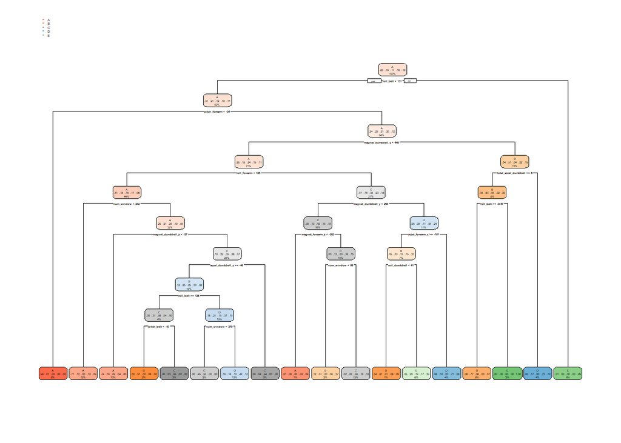

```r
mod_dt <- rpart(classe ~ ., data=subtraining, method="class")
rpart.plot(mod_dt)
```

```r
predict_dt <- predict(mod_dt, newdata=subtesting, type = "class")
cm_dt <- confusionMatrix(predict_dt, subtesting$classe)
cm_dt
```

```
## Confusion Matrix and Statistics
##
##           Reference
## Prediction    A    B    C    D    E
##          A 1928  286   10  136   99
##          B   41  754   47   24  131
##          C   29  166 1121  187  123
##          D  207  238  107  868  166
##          E   27   74   83   71  923
##
## Overall Statistics
##
##                Accuracy : 0.713
##                  95% CI : (0.7028, 0.723)
##     No Information Rate : 0.2845
##     P-Value [Acc > NIR] : < 2.2e-16
##
##                   Kappa : 0.6364
##
##  Mcnemar's Test P-Value : < 2.2e-16
##
## Statistics by Class:
##
##                      Class: A Class: B Class: C Class: D Class: E
## Sensitivity            0.8638   0.4967   0.8194   0.6750   0.6401
## Specificity            0.9054   0.9616   0.9220   0.8905   0.9602
## Pos Pred Value         0.7841   0.7563   0.6894   0.5473   0.7835
## Neg Pred Value         0.9436   0.8885   0.9603   0.9332   0.9222
## Prevalence             0.2845   0.1935   0.1744   0.1639   0.1838
## Detection Rate         0.2457   0.0961   0.1429   0.1106   0.1176
## Detection Prevalence   0.3134   0.1271   0.2072   0.2021   0.1501
## Balanced Accuracy      0.8846   0.7292   0.8707   0.7828   0.8001
```

2. Global Boosted Regression Models (GBM)

```r
mod_gbm <- train(classe ~ ., data = subtraining, method = "gbm", verbose="FALSE")
predictGBM <- predict(mod_gbm, newdata=subtesting)
cmGBM <- confusionMatrix(predictGBM, subtesting$classe)
cmGBM
```

```
## Confusion Matrix and Statistics
##
##           Reference
## Prediction    A    B    C    D    E
##          A 2230   18    0    0    1
##          B    1 1492   19    2    4
##          C    0    8 1348   15    0
##          D    1    0    1 1267   18
##          E    0    0    0    2 1419
##
## Overall Statistics
##
##                Accuracy : 0.9885
##                  95% CI : (0.9859, 0.9908)
##     No Information Rate : 0.2845
##     P-Value [Acc > NIR] : < 2.2e-16
##
##                   Kappa : 0.9855
##
##  Mcnemar's Test P-Value : NA
##
## Statistics by Class:
##
##                      Class: A Class: B Class: C Class: D Class: E
## Sensitivity            0.9991   0.9829   0.9854   0.9852   0.9840
## Specificity            0.9966   0.9959   0.9964   0.9970   0.9997
## Pos Pred Value         0.9916   0.9829   0.9832   0.9845   0.9986
## Neg Pred Value         0.9996   0.9959   0.9969   0.9971   0.9964
## Prevalence             0.2845   0.1935   0.1744   0.1639   0.1838
## Detection Rate         0.2842   0.1902   0.1718   0.1615   0.1809
## Detection Prevalence   0.2866   0.1935   0.1747   0.1640   0.1811
## Balanced Accuracy      0.9979   0.9894   0.9909   0.9911   0.9919
```

3. Linear Discriminant analysis (LDA)

```r
mod_lda <- train(classe ~ ., data = subtraining, method = "lda")
predictLDA <- predict(mod_lda, newdata=subtesting)
cmLDA <- confusionMatrix(predictLDA, subtesting$classe)
cmLDA
```

```
## Confusion Matrix and Statistics
##
##           Reference
## Prediction    A    B    C    D    E
##          A 1848  188  138   77   65
##          B   74  984  141   68  203
##          C  159  212  900  150  137
##          D  143   62  153  942  127
##          E    8   72   36   49  910
##
## Overall Statistics
##
##                Accuracy : 0.7117
##                  95% CI : (0.7015, 0.7217)
##     No Information Rate : 0.2845
##     P-Value [Acc > NIR] : < 2.2e-16
##
##                   Kappa : 0.6351
##
##  Mcnemar's Test P-Value : < 2.2e-16
##
## Statistics by Class:
##
##                      Class: A Class: B Class: C Class: D Class: E
## Sensitivity            0.8280   0.6482   0.6579   0.7325   0.6311
## Specificity            0.9166   0.9232   0.8984   0.9261   0.9742
## Pos Pred Value         0.7979   0.6694   0.5777   0.6601   0.8465
## Neg Pred Value         0.9306   0.9162   0.9256   0.9464   0.9214
## Prevalence             0.2845   0.1935   0.1744   0.1639   0.1838
## Detection Rate         0.2355   0.1254   0.1147   0.1201   0.1160
## Detection Prevalence   0.2952   0.1874   0.1986   0.1819   0.1370
## Balanced Accuracy      0.8723   0.7857   0.7782   0.8293   0.8027
```

## Predictions for the quiz

The GBM model has the best accuracy by far. The expected out of sample error stands around 1%. We’ll use it to answer the quiz questions.

```r
quiz <- predict(mod_gbm, newdata=testing)
quiz
```

```
##  [1] B A B A A E D B A A B C B A E E A B B B
## Levels: A B C D E
```